# Participation Rate based on Github Repository Public Events

```r
library(dplyr)
library(ggplot2)
library(reshape2)
```

# Overview

The purpose of this study is to determine if we can predict the overall participation level for a repository based on public Github event activity. The ultimate goal is to develop a sampling methodology for Github repositories based on this event activity.

This study is part of a larger research project to answer the following questions:

- What are the measurable impacts of Continuous Integration?
- What software projects would most likely benefit from Continuous Integration?

# Hypotheses

A sample drawn from repositories with a similar events-to-actor proportion will be less variable than a sample drawn from the entire Github population.

A sample drawn from an event type occurring most frequently for repositories in a given events-to-actor proportions will result in a larger proportion of repositories in the sample with that events-to-actor proportion. Therefore if one is interested in researching higher participation repositories active in the past month, one could take a random sample of events corresponding to the type occuring most frequently in high participation repositories.

Samples based on event type will be more variable than samples based on events-to-actor proportion but still less variable than samples taken from the entire event population.

Drawing repository samples from event types correlated with certain events-to-actor proportion results in a larger proportion of repositories matching the events-to-actor proportion.

# Null Hypothesis

Event types show no relationship to events-to-actor proportion such that samples drawn based on event type will show similar variability to samples drawn from the entire event population.

# Methodology

Because this research relied on additional GitHub repository data, samples were drawn from events occurring 60 days from when the research was initiated. Additional data was fetched via the Github API. The Github API uses rate limiting so sample sizes were limited to 100 events each.

# Experiments

For repositories in the each sample, additional event data were pulled from the GitHub Archive going back to 1/1/2016.

Each sample group explores the following parameters based on the events data:

- Event Types in Sample
- Event Type Frequency per Repository
- Repo Owner Frequency
- Actors per Repository
- Actors per Event Type per Repo
- Events per Actor Percent Frequency
- Repos per Owner in Sample

Each sample group explores the following parameters based on GitHub API data:

- Age and Last Update
- Language
- “Build Status” in README

## Event Samples Overview

### All Events

```r
all_events_repo_summary <- readRDS("all_events_repo_summary.rds")
all_events_repo_type_summary <- readRDS("all_events_repo_type_summary.rds")
```

### Push Events

Previous studies in this series have established that Push events are well represented across all levels of participation. We would expect the sample taken from Push Events to resemble the control sample in the previous section.

```r
push_events_repo_summary <- readRDS("push_events_repo_summary.rds")
push_events_repo_type_summary <- readRDS("push_events_repo_type_summary.rds")
```

### Watch Events

Previous studies in this series have established that Watch events are well represented across higher levels of participation. We would expect the sample taken from Watch Events to be larger projects with more contributors and end users.

```r
watch_events_repo_summary <- readRDS("watch_events_repo_summary.rds")
watch_events_repo_type_summary <- readRDS("watch_events_repo_type_summary.rds")
```

### Fork Events

Previous studies in this series have established that Fork events are well represented across higher levels of participation, but show a weaker correlation to the participation metrics used previously. Here, we explore how similar our results are to the repositories sampled through Watch Events.

```r
fork_events_repo_summary <- readRDS("fork_events_repo_summary.rds")
fork_events_repo_type_summary <- readRDS("fork_events_repo_type_summary.rds")
```

### Release Events

```r
release_events_repo_summary <- readRDS("release_events_repo_summary.rds")
release_events_repo_type_summary <- readRDS("release_events_repo_type_summary.rds")
```

## Event Types in Samples

### All Events

Our control sample is a sample of all events regardless of event type. We expect to see a lot of variation between the repositories.

The random sample of 100 events contained the following distribution of event types.

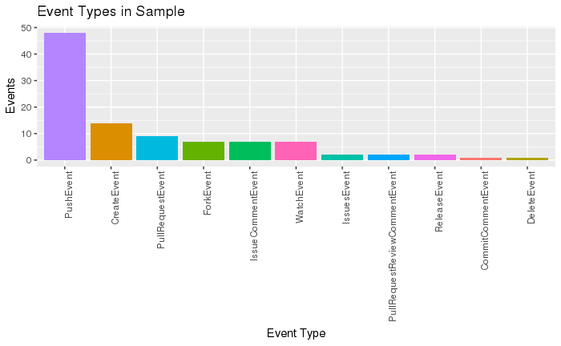

```r
all_sample_event_type_freq <- readRDS("all_sample_event_type_freq.rds")
ggplot(data = all_sample_event_type_freq,
       aes(x=reorder(type, -num_events),
       y=num_events, fill=type)) +
  geom_bar(stat="identity") +
  theme(legend.position="none") +
  ylab("Events") +
  xlab("Event Type") +
  theme(axis.text.x = element_text(angle = 90, hjust = 1)) +
  ggtitle("Event Types in Sample")
ggsave("all_sample_event_types.png")
```

## Event Type Frequency per Repository

How were event types distributed amongst repositories? The charts below count the number of repositories per event type frequency.

### All Events

Create and Push events were the best represented in this group. This is consistent with previous work that showed these as being the most frequent events overall.

```r
all_repo_event_type_freq <- all_events_repo_type_summary %>%
  group_by(type, num_events_log) %>%
  summarise(
    num_events_max = max(num_events),
    num_events_min = min(num_events),
    num_events_med = ceiling(median(num_events)),
    num_repos = n(),
    num_repos_log = round(log(num_repos)),
    sample = "all"
  )
```

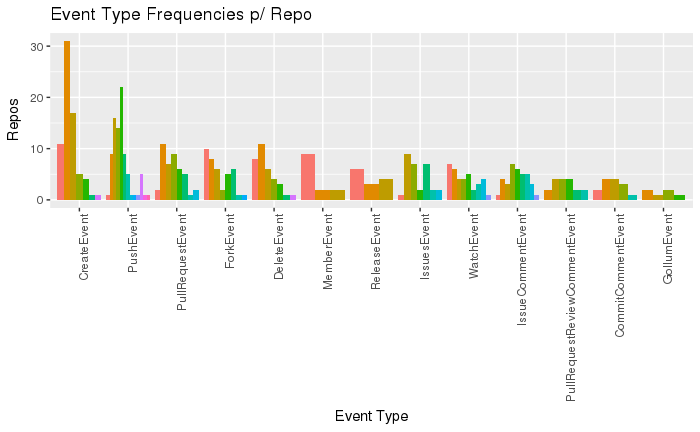

```r
ggplot(data = all_repo_event_type_freq,
       aes(x=reorder(type, -num_repos),
       y=num_repos,
       fill=factor(num_events_log))) +
  geom_bar(stat="identity", position="dodge") +
  theme(legend.position="none") +
  ylab("Repos") +
  xlab("Event Type") +
  theme(axis.text.x = element_text(angle = 90, hjust = 1)) +
  ggtitle("Event Type Frequencies p/ Repo")
ggsave("all_repo_event_type_freq.png")
```

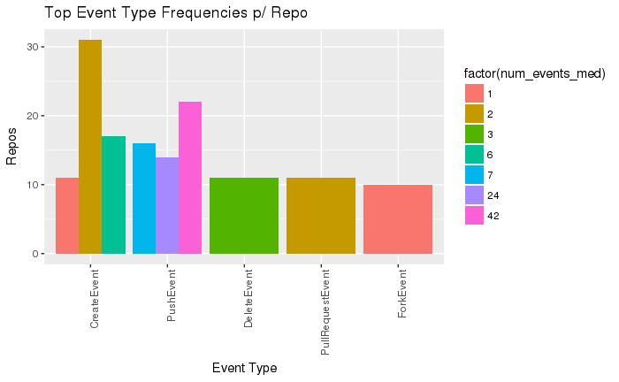

```r
all_repo_max_events <- all_repo_event_type_freq %>%
  filter(num_repos >= 10)
ggplot(data = all_repo_max_events,
       aes(x=reorder(type, -num_repos),
       y=num_repos,
       fill=factor(num_events_med))) +
  geom_bar(stat="identity", position="dodge") +
  ylab("Repos") +
  xlab("Event Type") +
  theme(axis.text.x = element_text(angle = 90, hjust = 1)) +
  ggtitle("Top Event Type Frequencies p/ Repo")
ggsave("all_repo_max_events.png")
```

### Push Events

```r
push_repo_event_type_freq <- push_events_repo_type_summary %>%
  group_by(type, num_events_log) %>%
  summarise(
    num_events_max = max(num_events),
    num_events_min = min(num_events),
    num_events_med = ceiling(median(num_events)),
    num_repos = n(),
    num_repos_log = round(log(num_repos)),
    sample = "push"
  )
```

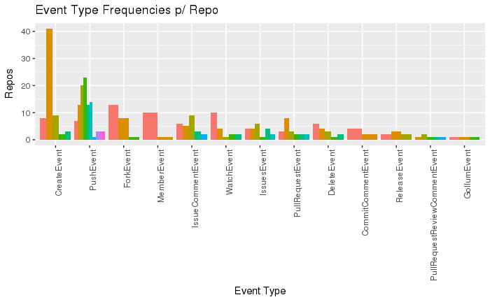

```r
ggplot(data = push_repo_event_type_freq,
       aes(x=reorder(type, -num_repos),
       y=num_repos,
       fill=factor(num_events_log))) +
  geom_bar(stat="identity", position="dodge") +
  theme(legend.position="none") +
  ylab("Repos") +
  xlab("Event Type") +
  theme(axis.text.x = element_text(angle = 90, hjust = 1)) +
  ggtitle("Event Type Frequencies p/ Repo")
ggsave("push_repo_event_type_freq.png")
```

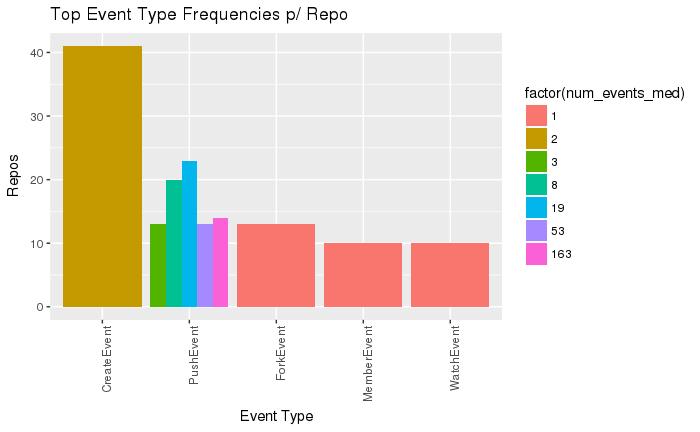

```r
push_repo_max_events <- push_repo_event_type_freq %>%
  filter(num_repos >= 10)
ggplot(data = push_repo_max_events,
       aes(x=reorder(type, -num_repos),
       y=num_repos,
       fill=factor(num_events_med))) +
  geom_bar(stat="identity", position="dodge") +
  ylab("Repos") +
  xlab("Event Type") +
  theme(axis.text.x = element_text(angle = 90, hjust = 1)) +
  ggtitle("Top Event Type Frequencies p/ Repo")
ggsave("push_repo_max_events.png")
```

### Watch Events

How were event types distributed amongst repositories? The charts below count the number of repositories per event type frequency.

```r
watch_repo_event_type_freq <- watch_events_repo_type_summary %>%
  group_by(type, num_events_log) %>%
  summarise(
    num_events_max = max(num_events),
    num_events_min = min(num_events),
    num_events_med = ceiling(median(num_events)),
    num_repos = n(),
    num_repos_log = round(log(num_repos)),
    sample = "watch"
  )
```

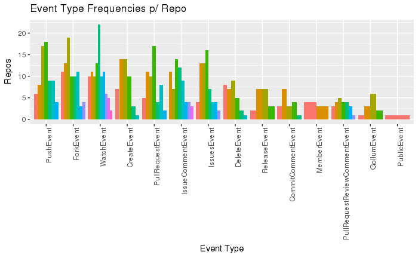

```r
ggplot(data = watch_repo_event_type_freq,
       aes(x=reorder(type, -num_repos),
       y=num_repos,
       fill=factor(num_events_log))) +
  geom_bar(stat="identity", position="dodge") +
  theme(legend.position="none") +
  ylab("Repos") +
  xlab("Event Type") +
  theme(axis.text.x = element_text(angle = 90, hjust = 1)) +
  ggtitle("Event Type Frequencies p/ Repo")
ggsave("watch_repo_event_type_freq.png")
```

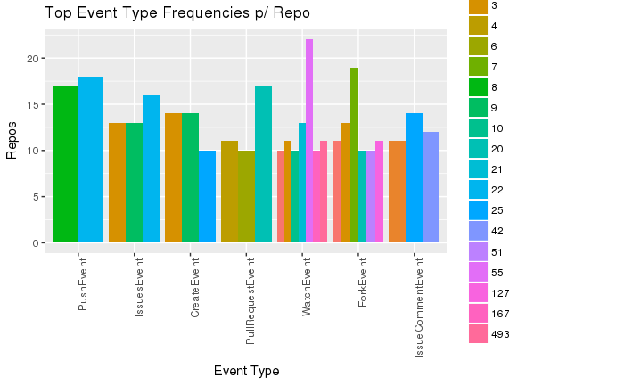

```r
watch_repo_max_events <- watch_repo_event_type_freq %>%
  filter(num_repos >= 10)
ggplot(data = watch_repo_max_events,
       aes(x=reorder(type, -num_repos),
       y=num_repos,
       fill=factor(num_events_med))) +
  geom_bar(stat="identity", position="dodge") +
  ylab("Repos") +
  xlab("Event Type") +
  theme(axis.text.x = element_text(angle = 90, hjust = 1)) +
  ggtitle("Top Event Type Frequencies p/ Repo")
ggsave("watch_repo_max_events.png")
```

### Fork Events

```r
fork_repo_event_type_freq <- fork_events_repo_type_summary %>%
  group_by(type, num_events_log) %>%
  summarise(
    num_events_max = max(num_events),
    num_events_min = min(num_events),
    num_events_med = ceiling(median(num_events)),
    num_repos = n(),
    num_repos_log = round(log(num_repos)),
    sample = "fork"
  )
```

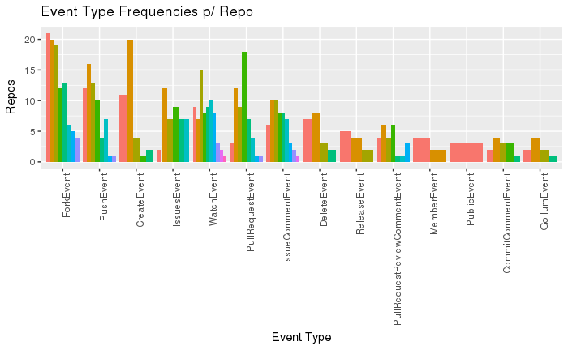

```r
ggplot(data = fork_repo_event_type_freq,
       aes(x=reorder(type, -num_repos),
       y=num_repos,
       fill=factor(num_events_log))) +
  geom_bar(stat="identity", position="dodge") +
  theme(legend.position="none") +
  ylab("Repos") +
  xlab("Event Type") +
  theme(axis.text.x = element_text(angle = 90, hjust = 1)) +
  ggtitle("Event Type Frequencies p/ Repo")
ggsave("fork_repo_event_type_freq.png")
```

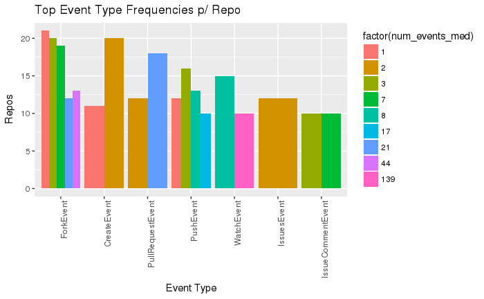

```r
fork_repo_max_events <- fork_repo_event_type_freq %>%
  filter(num_repos >= 10)
ggplot(data = fork_repo_max_events,
       aes(x=reorder(type, -num_repos),
       y=num_repos,
       fill=factor(num_events_med))) +
  geom_bar(stat="identity", position="dodge") +
  ylab("Repos") +
  xlab("Event Type") +
  theme(axis.text.x = element_text(angle = 90, hjust = 1)) +
  ggtitle("Top Event Type Frequencies p/ Repo")
ggsave("fork_repo_max_events.png")
```

### Release Events

```r
release_repo_event_type_freq <- release_events_repo_type_summary %>%
  group_by(type, num_events_log) %>%
  summarise(
    num_events_max = max(num_events),
    num_events_min = min(num_events),
    num_events_med = ceiling(median(num_events)),
    num_repos = n(),
    num_repos_log = round(log(num_repos)),
    sample = "release"
  )
```

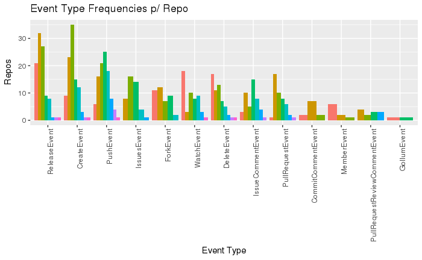

```r
ggplot(data = release_repo_event_type_freq,
       aes(x=reorder(type, -num_repos),
       y=num_repos,
       fill=factor(num_events_log))) +
  geom_bar(stat="identity", position="dodge") +
  theme(legend.position="none") +
  ylab("Repos") +
  xlab("Event Type") +
  theme(axis.text.x = element_text(angle = 90, hjust = 1)) +
  ggtitle("Event Type Frequencies p/ Repo")
ggsave("release_repo_event_type_freq.png")
```

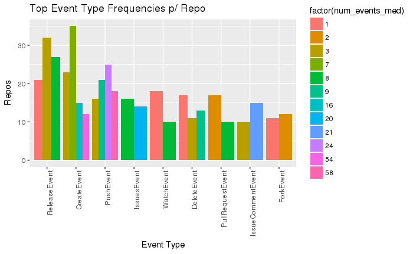

```r
release_repo_max_events <- release_repo_event_type_freq %>%
  filter(num_repos >= 10)
ggplot(data = release_repo_max_events,
       aes(x=reorder(type, -num_repos),
       y=num_repos,
       fill=factor(num_events_med))) +
  geom_bar(stat="identity", position="dodge") +
  ylab("Repos") +
  xlab("Event Type") +
  theme(axis.text.x = element_text(angle = 90, hjust = 1)) +
  ggtitle("Top Event Type Frequencies p/ Repo")
ggsave("release_repo_max_events.png")
```

### Summary

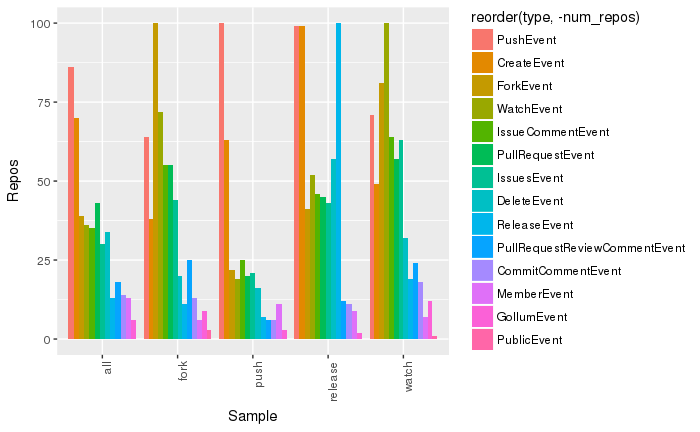

```r
repo_event_type_freq <- bind_rows(all_repo_event_type_freq, push_repo_event_type_freq, watch_repo_event_type_freq, fork_repo_event_type_freq, release_repo_event_type_freq)
repo_event_type_freq_summary <- repo_event_type_freq %>%
  group_by(sample, type) %>%
  summarise(
    num_events_buckets_count = n(),
    num_events_min = min(num_events_min),
    num_events_max = max(num_events_max),
    num_events_med = median(num_events_med),
    num_repos = sum(num_repos)
  ) %>%
  mutate(num_repos_quartile = ntile(num_repos, 4))
repo_event_type_freq_summary_top <- repo_event_type_freq_summary %>%
  filter(num_repos_quartile >= 3)
ggplot(data = repo_event_type_freq_summary,
       aes(x=sample, y=num_repos, fill=reorder(type, -num_repos))) +
  geom_bar(stat="identity", position="dodge") +
  #theme(legend.position="none") +
  ylab("Repos") +
  xlab("Sample") +
  theme(axis.text.x = element_text(angle = 90, hjust = 1))
ggsave("repo_event_type_freq_summary.png")
```

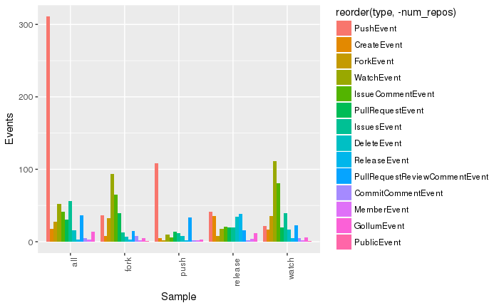

```r
ggplot(data = repo_event_type_freq_summary,
       aes(x=sample, y=num_events_med, fill=reorder(type, -num_repos))) +
  geom_bar(stat="identity", position="dodge") +
  #theme(legend.position="none") +
  ylab("Events") +
  xlab("Sample") +
  theme(axis.text.x = element_text(angle = 90, hjust = 1))
```

```r
repo_event_type_freq_repo_summary <- repo_event_type_freq %>%
  group_by(sample, type, num_repos_log) %>%
  summarise(
    num_repos = sum(num_repos),
    num_events_min = min(num_events_min),
    num_events_med = ceiling(median(num_events_med)),
    num_events_max = max(num_events_max),
    num_events_log_min = min(num_events_log),
    num_events_log_max = max(num_events_log),
    buckets = n()
  )
  repo_event_type_freq_repo_summary_top <- repo_event_type_freq_repo_summary %>% ungroup() %>%
    group_by(type, sample) %>%
    slice(which.max(num_repos_log))
```

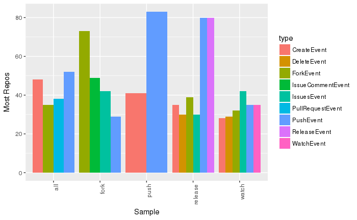

```r
ggplot(data = repo_event_type_freq_repo_summary_top %>% filter(num_repos > 25),
       aes(x=sample,
       y=num_repos,
       fill=type)) +
  geom_bar(stat="identity", position="dodge") +
  #theme(legend.position="none") +
  ylab("Most Repos") +
  xlab("Sample") +
  theme(axis.text.x = element_text(angle = 90, hjust = 1))
ggsave("repo_event_type_freq_summary_num_repos.png")
```

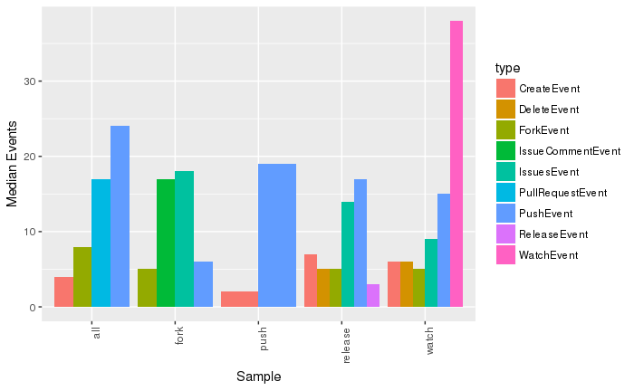

```r
ggplot(data = repo_event_type_freq_repo_summary_top %>% filter(num_repos > 25),
       aes(x=sample,
       y=num_events_med,
       fill=type)) +
  geom_bar(stat="identity", position="dodge") +
  #theme(legend.position="none") +
  ylab("Median Events") +
  xlab("Sample") +
  theme(axis.text.x = element_text(angle = 90, hjust = 1))
ggsave("repo_event_type_freq_summary_num_events_med.png")
```

Deviation from the “all” sample

```r
repo_event_type_freq_repo_summary_top <- repo_event_type_freq_repo_summary_top %>% ungroup()
all_repo_event_type_freq_type_summary <- repo_event_type_freq_repo_summary_top %>%
  filter(sample == "all") %>%
  group_by(type) %>%
  slice(which.max(num_repos_log)) %>%
  mutate(control_num_events_log_min = num_events_log_min,
         control_num_events_log_max = num_events_log_max,
         control_num_events_max = num_events_max,
         control_num_events_med = num_events_med,
         control_num_repos = num_repos,
         control_num_repos_log = num_repos_log) %>%
  select(type, control_num_events_log_min, control_num_events_log_max, control_num_events_max, control_num_events_med, control_num_repos_log, control_num_repos)
repo_event_type_variability <- merge(repo_event_type_freq_repo_summary_top,
                                     all_repo_event_type_freq_type_summary,
                                     by="type")
repo_event_type_variability <- repo_event_type_variability %>%
  mutate(num_events_log_max_diff = num_events_log_max - control_num_events_log_max,
         num_events_log_min_diff = num_events_log_min - control_num_events_log_min,
         num_events_max_diff = num_events_max - control_num_events_max,
         num_events_med_diff = num_events_med - control_num_events_med,
         num_repos_diff = num_repos - control_num_repos,
         num_repos_log_diff = num_repos_log - control_num_repos_log,
         # does the sample deviate more from the control sample than the control sample deviates from pop?
         num_events_log_max_dev = ifelse(num_events_log_max_diff < control_num_events_log_max, 1, 0),
         num_events_log_min_dev = ifelse(num_events_log_min_diff < control_num_events_log_min, 1, 0),
         num_repos_log_dev = ifelse(abs(num_repos_log_diff) > 0, 1, 0)
         ) %>%
  filter(sample != "all")
```

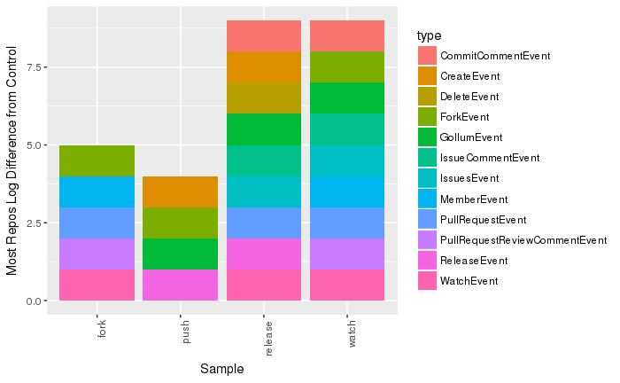

```r
repo_event_type_variability_repos <- repo_event_type_variability %>%
  filter(num_repos_log_dev == 1)
ggplot(data = repo_event_type_variability_repos,
       aes(x=sample,
       y=abs(num_repos_log_diff),
       fill=type)) +
  geom_bar(stat="identity", position="stack") +
  ylab("Most Repos Log Difference from Control") +
  xlab("Sample") +
  theme(axis.text.x = element_text(angle = 90, hjust = 1))
ggsave("repo_event_type_variability_repos_log.png")
```

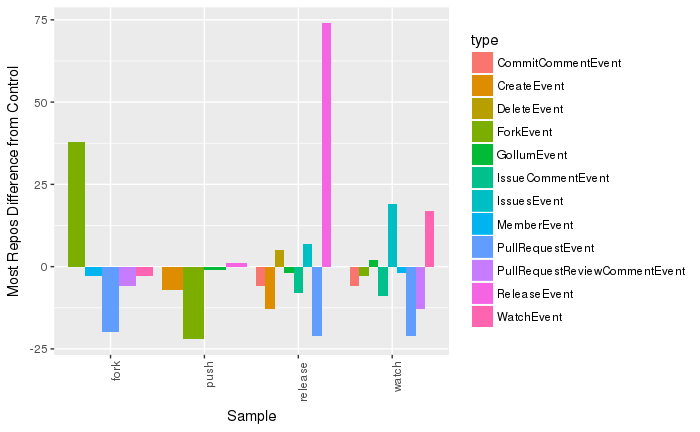

```r
ggplot(data = repo_event_type_variability_repos,
       aes(x=sample,
       y=num_repos_diff,
       fill=type)) +
  geom_bar(stat="identity", position="dodge") +
  ylab("Most Repos Difference from Control") +
  xlab("Sample") +
  theme(axis.text.x = element_text(angle = 90, hjust = 1))
ggsave("repo_event_type_variability_repos.png")
```

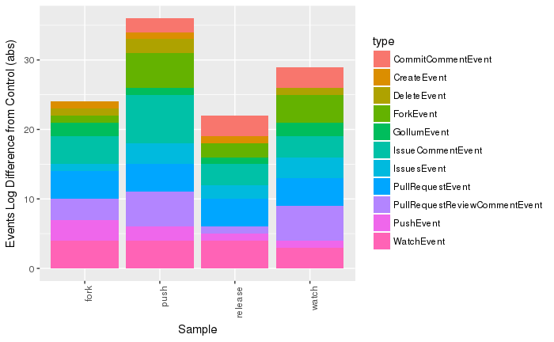

```r
repo_event_type_variability_events <- repo_event_type_variability %>% filter(num_events_log_max_dev == 1 | num_events_log_min_dev == 1)
ggplot(data = repo_event_type_variability_events,
       aes(x=sample,
       y=abs(num_events_log_max_diff) + abs(num_events_log_min_diff),
       fill=type)) +
  geom_bar(stat="identity", position="stack") +
  ylab("Events Log Difference from Control (abs)") +
  xlab("Sample") +
  theme(axis.text.x = element_text(angle = 90, hjust = 1))
ggsave("repo_event_type_variability_events_log.png")
```

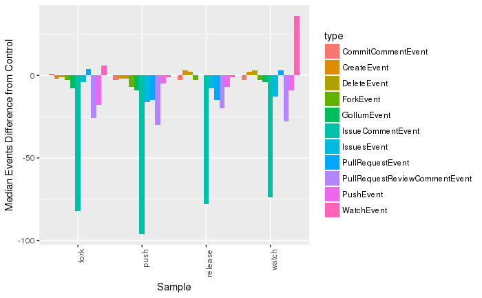

```r
ggplot(data = repo_event_type_variability_events,
       aes(x=sample,
       y=num_events_med_diff,
       fill=type)) +
  geom_bar(stat="identity", position="dodge") +
  ylab("Median Events Difference from Control") +
  xlab("Sample") +
  theme(axis.text.x = element_text(angle = 90, hjust = 1))
ggsave("repo_event_type_variability_events.png")
```

## Actors per Repository

### All Events

In the sample, 3/4 of the repositories had 1-12 unique actors in 15 months.

```r
all_repo_actors_freq <- all_events_repo_summary %>%
  group_by(total_actors_log) %>%
  summarise(
    total_actors_max = max(total_actors),
    total_actors_min = min(total_actors),
    total_actors_med = ceiling(median(total_actors)),
    num_repos = n(),
    num_repos_log = round(log(num_repos)),
    sample = "all"
  )
```

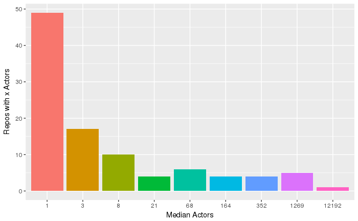

```r
ggplot(data = all_repo_actors_freq,
       aes(x = factor(total_actors_med),
           y = num_repos,
           fill=factor(total_actors_log))) +
  geom_bar(stat="identity", position="stack") +
  theme(legend.position="none") +
  ylab("Repos with x Actors") +
  xlab("Median Actors")
ggsave("all_repo_actors_freq.png")
```

### Push Events

```r
push_repo_actors_freq <- push_events_repo_summary %>%
  group_by(total_actors_log) %>%
  summarise(
    total_actors_max = max(total_actors),
    total_actors_min = min(total_actors),
    total_actors_med = ceiling(median(total_actors)),
    num_repos = n(),
    num_repos_log = round(log(num_repos)),
    sample = "push"
  )
```

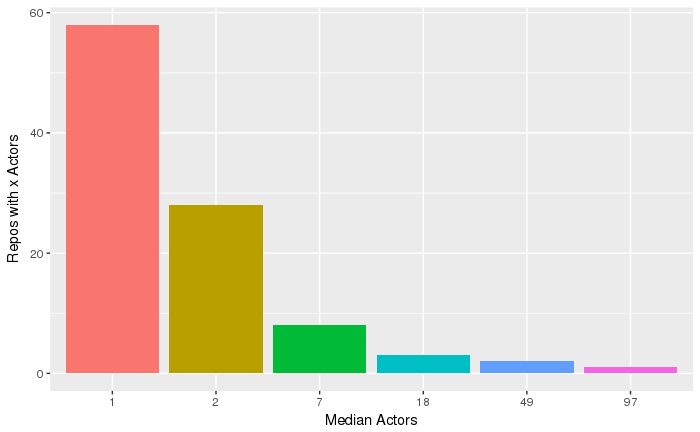

```r
ggplot(data = push_repo_actors_freq,
       aes(x = factor(total_actors_med),
           y = num_repos,
           fill=factor(total_actors_log))) +
  geom_bar(stat="identity", position="stack") +
  theme(legend.position="none") +
  ylab("Repos with x Actors") +
  xlab("Median Actors")
ggsave("push_repo_actors_freq.png")
```

### Watch Events

```r
watch_repo_actors_freq <- watch_events_repo_summary %>%
  group_by(total_actors_log) %>%
  summarise(
    total_actors_max = max(total_actors),
    total_actors_min = min(total_actors),
    total_actors_med = ceiling(median(total_actors)),
    num_repos = n(),
    num_repos_log = round(log(num_repos)),
    sample = "watch"
  )
```

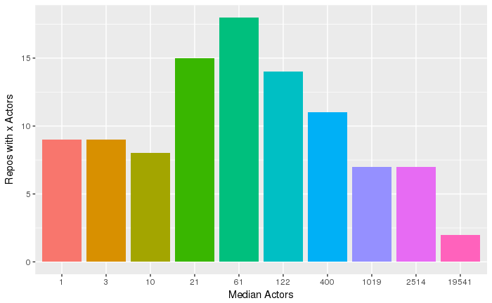

```r
ggplot(data = watch_repo_actors_freq,
       aes(x = factor(total_actors_med),
           y = num_repos,
           fill=factor(total_actors_log))) +
  geom_bar(stat="identity", position="stack") +
  theme(legend.position="none") +
  ylab("Repos with x Actors") +
  xlab("Median Actors")
ggsave("watch_repo_actors_freq.png")
```

### Fork Events

```r
fork_repo_actors_freq <- fork_events_repo_summary %>%
  group_by(total_actors_log) %>%
  summarise(
    total_actors_max = max(total_actors),
    total_actors_min = min(total_actors),
    total_actors_med = ceiling(median(total_actors)),
    num_repos = n(),
    num_repos_log = round(log(num_repos)),
    sample = "fork"
  )
```

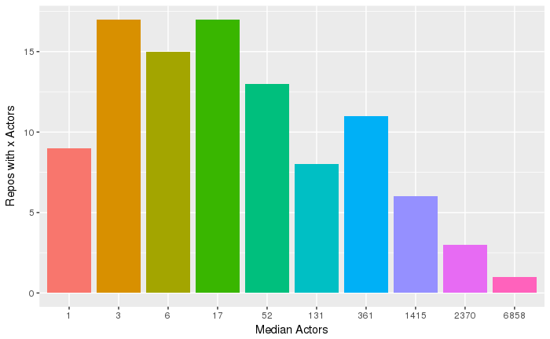

```r
ggplot(data = fork_repo_actors_freq,
       aes(x = factor(total_actors_med),
           y = num_repos,
           fill=factor(total_actors_log))) +
  geom_bar(stat="identity", position="stack") +
  theme(legend.position="none") +
  ylab("Repos with x Actors") +
  xlab("Median Actors")
ggsave("fork_repo_actors_freq.png")
```

### Release Events

In the sample, 3/4 of the repositories had 1-12 unique actors in 15 months.

```r
release_repo_actors_freq <- release_events_repo_summary %>%
  group_by(total_actors_log) %>%
  summarise(
    total_actors_max = max(total_actors),
    total_actors_min = min(total_actors),
    total_actors_med = ceiling(median(total_actors)),
    num_repos = n(),
    num_repos_log = round(log(num_repos)),
    sample = "release"
  )
```

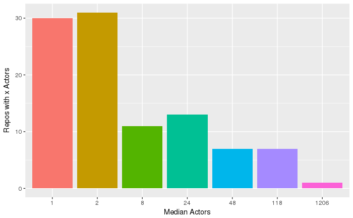

```r
ggplot(data = release_repo_actors_freq,
       aes(x = factor(total_actors_med),
           y = num_repos,
           fill=factor(total_actors_log))) +
  geom_bar(stat="identity", position="stack") +
  theme(legend.position="none") +
  ylab("Repos with x Actors") +
  xlab("Median Actors")
ggsave("release_repo_actors_freq.png")
```

### Summary

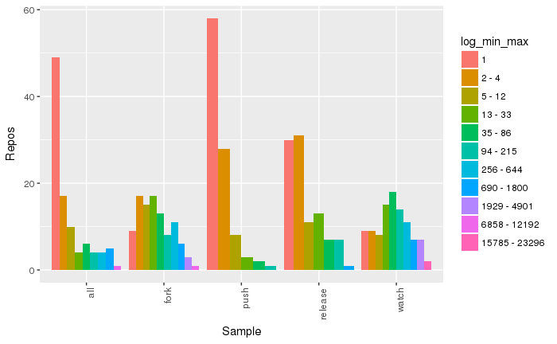

```r
repo_actors_freq <- bind_rows(all_repo_actors_freq, push_repo_actors_freq, watch_repo_actors_freq, fork_repo_actors_freq, release_repo_actors_freq)
repo_actors_freq_log <- repo_actors_freq %>%
  group_by(total_actors_log) %>%
  summarise(
    log_min = min(total_actors_min),
    log_max = max(total_actors_max)) %>%
  mutate(log_min_max = ifelse(log_min == log_max,
                         log_max,
                         paste(log_min,"-",log_max)))
repo_actors_freq <- merge(repo_actors_freq_log, repo_actors_freq, by="total_actors_log")
repo_actors_freq$log_min_max <- factor(repo_actors_freq$log_min_max,
                                       levels=unique(
                                           repo_actors_freq$log_min_max[
                                             order(repo_actors_freq$total_actors_log)]))
ggplot(data = repo_actors_freq,
       aes(x=sample, y=num_repos, fill=log_min_max)) +
  geom_bar(stat="identity", position="dodge") +
  ylab("Repos") +
  xlab("Sample") +
  theme(axis.text.x = element_text(angle = 90, hjust = 1))
ggsave("repo_actors_freq.png")
```

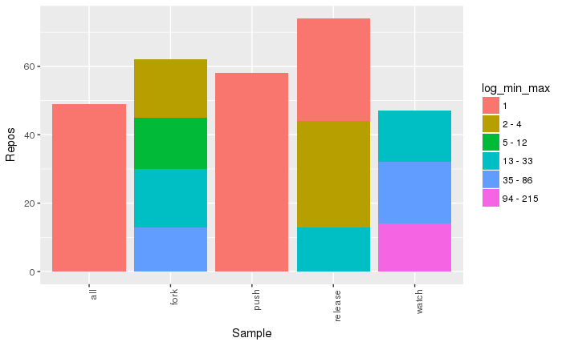

```r
repo_actors_freq <- repo_actors_freq %>%
  group_by(sample) %>%
  mutate(num_repos_log_max = max(num_repos_log))
repo_actors_freq_summary_top <- repo_actors_freq %>%
  filter(num_repos_log == num_repos_log_max)
ggplot(data = repo_actors_freq_summary_top,
       aes(x=sample, y=num_repos, fill=log_min_max)) +
  geom_bar(stat="identity", position="stack") +
  ylab("Repos") +
  xlab("Sample") +
  theme(axis.text.x = element_text(angle = 90, hjust = 1))
ggsave("repo_actors_freq_summary_top.png")
```

## Actors per Event Type per Repo

### All Events

The majority of repositories in the sample had 1-4 unique actors per event type.

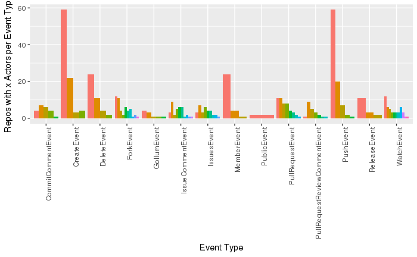

```r
all_repo_event_type_actors_freq <- readRDS("all_repo_event_type_actors_freq.rds")
ggplot(data = all_repo_event_type_actors_freq,
       aes(x = type,
           y = num_repos,
           fill=factor(num_actors_log))) +
  geom_bar(stat="identity", position="dodge") +
  theme(legend.position="none") +
  ylab("Repos with x Actors per Event Type") +
  xlab("Event Type") +
  theme(axis.text.x = element_text(angle = 90, hjust = 1))
ggsave("all_repo_event_type_actors_freq.png")
```

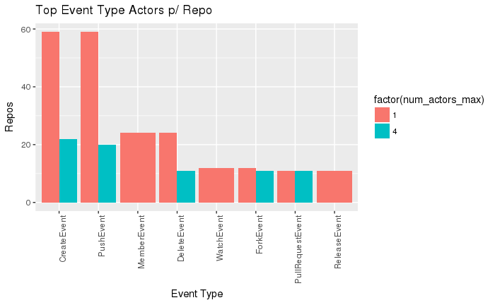

```r
all_repo_max_actors <- all_repo_event_type_actors_freq %>%
  filter(num_repos >= 10)
ggplot(data = all_repo_max_actors,
       aes(x=reorder(type, -num_repos),
       y=num_repos,
       fill=factor(num_actors_max))) +
  geom_bar(stat="identity", position="dodge") +
  ylab("Repos") +
  xlab("Event Type") +
  theme(axis.text.x = element_text(angle = 90, hjust = 1)) +
  ggtitle("Top Event Type Actors p/ Repo")
ggsave("all_repo_max_actors.png")
```

### Push Events

```r
push_repo_type_actors_freq <- push_events_repo_type_summary %>%
  group_by(type, num_actors_log) %>%
  summarise(
    num_actors_max = max(num_actors),
    num_actors_min = min(num_actors),
    num_repos = n()
  )
```

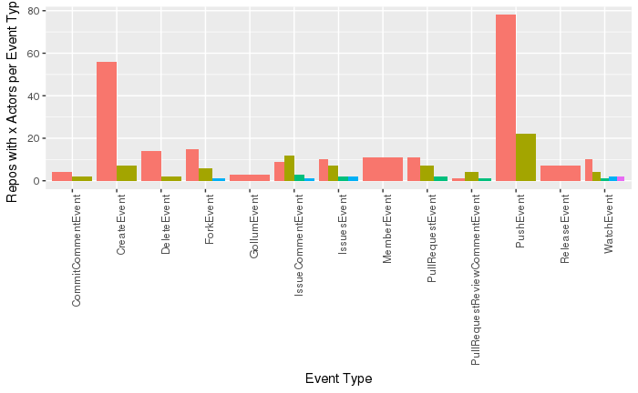

```r
ggplot(data = push_repo_type_actors_freq,
       aes(x = type,
           y = num_repos,
           fill=factor(num_actors_log))) +
  geom_bar(stat="identity", position="dodge") +
  theme(legend.position="none") +
  ylab("Repos with x Actors per Event Type") +
  xlab("Event Type") +
  theme(axis.text.x = element_text(angle = 90, hjust = 1))
ggsave("push_repo_event_type_actors_freq.png")
```

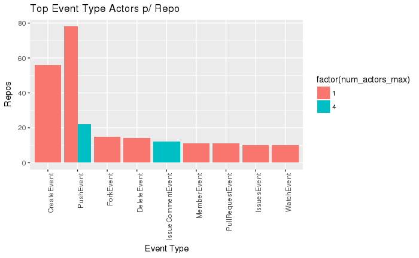

```r
push_repo_max_actors <- push_repo_type_actors_freq %>%
  filter(num_repos >= 10)
ggplot(data = push_repo_max_actors,
       aes(x=reorder(type, -num_repos),
       y=num_repos,
       fill=factor(num_actors_max))) +
  geom_bar(stat="identity", position="dodge") +
  ylab("Repos") +
  xlab("Event Type") +
  theme(axis.text.x = element_text(angle = 90, hjust = 1)) +
  ggtitle("Top Event Type Actors p/ Repo")
ggsave("push_repo_max_actors.png")
```